# Code Switching Analysis Morini Lab

JM Schneider

2020-06-25

*Summary Statement*: Code switching between Spanish and English significantly changes as children progress from kindergarten through second grade. This is driven by significantly less code switching in English, but not Spanish.

## 0.1 Library Import

## 0.2 Import and merge data

## 0.3 Cleaned Data

```r
df= read.csv("cs_combined_data_clean.csv", header = TRUE)
```

### 0.3.1 Format Dataframe

## 0.4 Identify Outliers

### 0.4.1 Merge NDW and NTW within language with larger dataframe

### 0.4.2 Remove subjects containing two grades

### 0.4.3 Sanity Check of Data

## 0.5 ANOVA Model: Does code switching in each language change across grade levels?

```r
# overall_datpoint_model <- lm(Prop.Utt.CS ~ Gender + Language*Data.Point, data = df)
# summary(overall_datpoint_model)
#
# overall_grade_wave_model <- lm(Prop.Utt.CS ~ Gender + Language*wave*Grade, data = df)
# summary(overall_grade_wave_model)
#
# noout_datpoint_model <- lm(Prop.Utt.CS ~ Gender + Language*Data.Point, data = df_no_out)
# summary(noout_datpoint_model)


fit <- lmer(Prop.Utt.CS ~ Gender + Language*wave*Grade + (1|subject), data = df_no_out)
summary(fit)
```

```
## Linear mixed model fit by REML. t-tests use Satterthwaite's method [
## lmerModLmerTest]
## Formula: Prop.Utt.CS ~ Gender + Language * wave * Grade + (1 | subject)
##    Data: df_no_out
##
## REML criterion at convergence: -6546.5
##
## Scaled residuals:
##     Min      1Q  Median      3Q     Max
## -1.6564 -0.3953 -0.2118  0.1244 13.6160
##
## Random effects:
##  Groups   Name        Variance  Std.Dev.
##  subject  (Intercept) 0.0002717 0.01648
##  Residual             0.0032546 0.05705
## Number of obs: 2340, groups:  subject, 195
##
## Fixed effects:
##                                    Estimate Std. Error         df t value
## (Intercept)                       5.168e-02  4.159e-03  1.564e+03  12.424
## GenderM                           3.032e-03  3.376e-03  1.955e+02   0.898
## LanguageSPANISH                  -2.760e-02  5.274e-03  2.138e+03  -5.233
## wavespring                       -1.790e-02  5.274e-03  2.138e+03  -3.393
## Grade                            -2.333e-02  2.889e-03  2.138e+03  -8.075
## LanguageSPANISH:wavespring        1.129e-02  7.459e-03  2.138e+03   1.513
## LanguageSPANISH:Grade             2.069e-02  4.085e-03  2.138e+03   5.065
## wavespring:Grade                  4.654e-03  4.085e-03  2.138e+03   1.139
## LanguageSPANISH:wavespring:Grade  2.634e-03  5.778e-03  2.138e+03   0.456
##                                  Pr(>|t|)
## (Intercept)                       < 2e-16 ***
## GenderM                          0.370134
## LanguageSPANISH                  1.83e-07 ***
## wavespring                       0.000703 ***
## Grade                            1.12e-15 ***
## LanguageSPANISH:wavespring       0.130358
## LanguageSPANISH:Grade            4.43e-07 ***
## wavespring:Grade                 0.254771
## LanguageSPANISH:wavespring:Grade 0.648469
## ---
## Signif. codes:  0 '***' 0.001 '**' 0.01 '*' 0.05 '.' 0.1 ' ' 1
##
## Correlation of Fixed Effects:
##             (Intr) GendrM LnSPANISH wvsprn Grade  LnSPANISH: LSPANISH:G
## GenderM     -0.340
## LnggSPANISH -0.634 -0.001
## wavespring  -0.634 -0.001  0.500
## Grade       -0.695  0.000  0.548     0.548
## LngSPANISH:  0.448  0.002 -0.707    -0.707 -0.387
## LnSPANISH:G  0.491  0.000 -0.775    -0.387 -0.707  0.548
## wvsprng:Grd  0.491  0.000 -0.387    -0.775 -0.707  0.548      0.500
## LSPANISH::G -0.347  0.000  0.548     0.548  0.500 -0.775     -0.707
##             wvsp:G
## GenderM
## LnggSPANISH
## wavespring
## Grade
## LngSPANISH:
## LnSPANISH:G
## wvsprng:Grd
## LSPANISH::G -0.707
```

```r
effectsize(fit)
```

```
## Parameter                        | Coefficient (std.) |         95% CI
## ----------------------------------------------------------------------
## (Intercept)                      |               0.09 | [-0.01,  0.18]
## GenderM                          |               0.05 | [-0.06,  0.16]
## LanguageSPANISH                  |              -0.11 | [-0.22, -0.01]
## wavespring                       |              -0.22 | [-0.33, -0.11]
## Grade                            |              -0.31 | [-0.39, -0.24]
## LanguageSPANISH:wavespring       |               0.23 | [ 0.08,  0.38]
## LanguageSPANISH:Grade            |               0.28 | [ 0.17,  0.39]
## wavespring:Grade                 |               0.06 | [-0.05,  0.17]
## LanguageSPANISH:wavespring:Grade |               0.04 | [-0.12,  0.19]
```

## 0.6 Grade x Language Interaction:

Children have proportionally fewer code switches in English across the course of K-2 grades, but there is no change in Spanish code switching across grades. Children proportionally code switch *significantly* less from K-1st grade AND 1st-2nd grade. Proportion of code switches between languages significantly differed at each grade.

### 0.6.1 Post hoc tests to breakdown interaction

```r
span_df <- df_no_out[which(df_no_out$Language == 'SPANISH'),]
eng_df <- df_no_out[which(df_no_out$Language == 'ENGLISH'),]

eng.one.model <- aov(Prop.Utt.CS ~ Grade, data = eng_df)
span.one.model <- aov(Prop.Utt.CS ~ Grade, data = span_df)

summary(eng.one.model)
```

```
##               Df Sum Sq Mean Sq F value Pr(>F)
## Grade          1  0.344  0.3440   69.93 <2e-16 ***
## Residuals   1168  5.745  0.0049
## ---
## Signif. codes:  0 '***' 0.001 '**' 0.01 '*' 0.05 '.' 0.1 ' ' 1
```

```r
summary(span.one.model)
```

```
##               Df Sum Sq   Mean Sq F value Pr(>F)
## Grade          1 0.0008 0.0007955   0.366  0.546
## Residuals   1168 2.5416 0.0021761
```

```r
df_K.1 <- eng_df[which(eng_df$Grade <= 1),]
#K.2_df <- eng_df[which(eng_df$Grade != 1),]
df_1.2 <- eng_df[which(eng_df$Grade >= 1),]
t.test(df_K.1$Grade, df_K.1$Prop.Utt.CS, paired = TRUE, alternative = "two.sided")
```

```
##
##  Paired t-test
##
## data:  df_K.1$Grade and df_K.1$Prop.Utt.CS
## t = 24.968, df = 779, p-value < 2.2e-16
## alternative hypothesis: true difference in means is not equal to 0
## 95 percent confidence interval:
##  0.4318537 0.5055546
## sample estimates:
## mean of the differences
##               0.4687042
```

```r
#t.test(K.2_df$Grade, K.2_df$CS_count, paired = TRUE, alternative = "two.sided")
t.test(df_1.2$Grade, df_1.2$Prop.Utt.CS, paired = TRUE, alternative = "two.sided")
```

```
##
##  Paired t-test
##
## data:  df_1.2$Grade and df_1.2$Prop.Utt.CS
## t = 82.284, df = 779, p-value < 2.2e-16
## alternative hypothesis: true difference in means is not equal to 0
## 95 percent confidence interval:
##  1.454165 1.525243
## sample estimates:
## mean of the differences
##                1.489704
```

```r
k_df <- df_no_out[which(df_no_out$Grade == 0),]
first_df <- df_no_out[which(df_no_out$Grade == 1),]
second_df <- df_no_out[which(df_no_out$Grade == 2),]

t.test(k_df$Prop.Utt.CS~k_df$Language, paired = TRUE, alternative = "two.sided")
```

```
##
##  Paired t-test
##
## data:  k_df$Prop.Utt.CS by k_df$Language
## t = 4.2462, df = 389, p-value = 2.722e-05
## alternative hypothesis: true difference in means is not equal to 0
## 95 percent confidence interval:
##  0.01389742 0.03786383
## sample estimates:
## mean of the differences
##              0.02588063
```

```r
t.test(first_df$Prop.Utt.CS~first_df$Language, paired = TRUE, alternative = "two.sided")
```

```
##
##  Paired t-test
##
## data:  first_df$Prop.Utt.CS by first_df$Language
## t = -2.249, df = 389, p-value = 0.02507
## alternative hypothesis: true difference in means is not equal to 0
## 95 percent confidence interval:
##  -0.0147967887 -0.0009932316
## sample estimates:
## mean of the differences
##             -0.00789501
```

```r
t.test(second_df$Prop.Utt.CS~second_df$Language, paired = TRUE, alternative = "two.sided")
```

```
##
##  Paired t-test
##
## data:  second_df$Prop.Utt.CS by second_df$Language
## t = -8.1503, df = 389, p-value = 5.025e-15
## alternative hypothesis: true difference in means is not equal to 0
## 95 percent confidence interval:
##  -0.02251418 -0.01376307
## sample estimates:
## mean of the differences
##             -0.01813863
```

### 0.6.2 Calculate means and SE for each group of interest

### 0.6.3 Plot means and SE

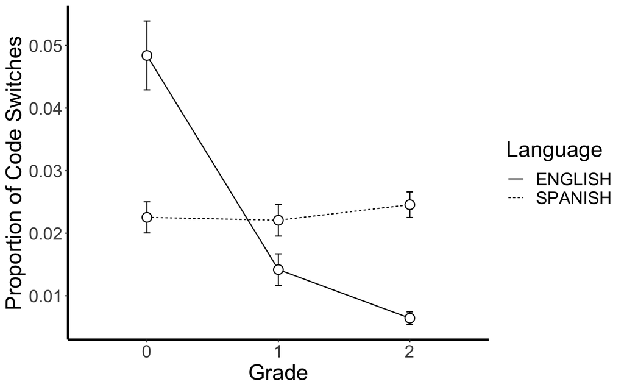

```r
pd <- position_dodge(width = 0)
sum_d %>%
  ggplot(aes(x = Grade, y = CS_prop_mean, group = Language)) +
    geom_line(aes(linetype = Language), position = pd) +
    geom_errorbar(aes(ymin = CS_prop_mean - se, ymax = CS_prop_mean + se),
                  width = .1, position = pd) +
    geom_point(size = 4, position = pd) +
    geom_point(size = 3, color = "white", position = pd) +
    guides(linetype = guide_legend("Language")) +
    labs(x = "Grade",
         y = "Proportion of Code Switches") +
  theme(
    text=element_text(size=20),
    panel.background = element_rect(fill = "white"),         # Set plot background to white
    legend.key  = element_rect(fill = "white"),              # Set legend item backgrounds to white
    axis.line.x = element_line(colour = "black", size = 1),  # Add line to x axis
    axis.line.y = element_line(colour = "black", size = 1)   # Add line to y axis
  )
```

## 0.7 Main Effect of Wave:

```r
t.test(df_no_out$Prop.Utt.CS~df_no_out$wave, paired = TRUE)
```

```
##
##  Paired t-test
##
## data:  df_no_out$Prop.Utt.CS by df_no_out$wave
## t = 2.9922, df = 1169, p-value = 0.002828
## alternative hypothesis: true difference in means is not equal to 0
## 95 percent confidence interval:
##  0.002163344 0.010403296
## sample estimates:
## mean of the differences
##              0.00628332
```

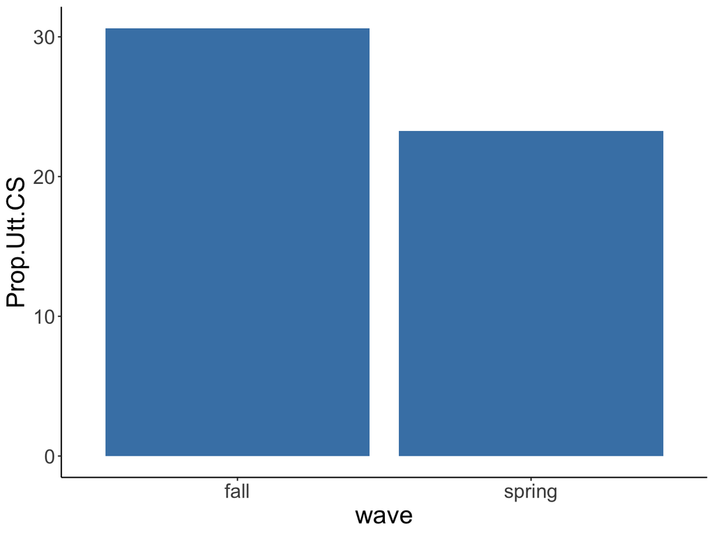

```r
p <- ggplot(df_no_out, aes(x=wave, y=Prop.Utt.CS)) +
  geom_bar(stat="identity",fill="steelblue") + julie.theme + theme(text = element_text(size=20))
p
```

## 0.8 Main Effect of Language:

The proportion of utterances does not differ on the basis of language alone. In the omnnibus model, there were significantly fewer CS utterances for Spanish than for English. The reason this does not come out in the t.test relates to all the other covariates in the larger model, indicating it isn’t JUST about the language – period of development/wave matter.

```r
t.test(df_no_out$Prop.Utt.CS~df_no_out$Language, paired = TRUE)
```

```
##
##  Paired t-test
##
## data:  df_no_out$Prop.Utt.CS by df_no_out$Language
## t = -0.020257, df = 1169, p-value = 0.9838
## alternative hypothesis: true difference in means is not equal to 0
## 95 percent confidence interval:
##  -0.004990954  0.004888948
## sample estimates:
## mean of the differences
##           -5.100282e-05
```

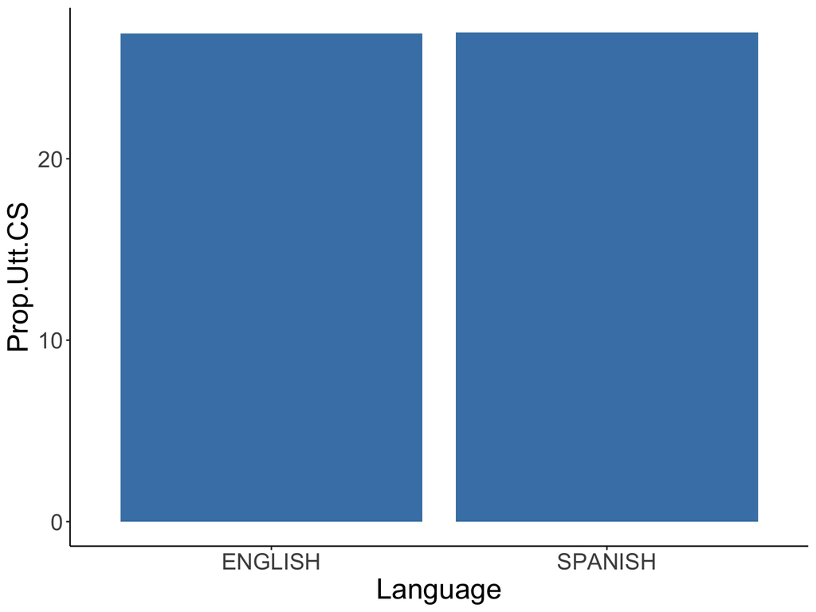

```r
p <- ggplot(df_no_out, aes(x=Language, y=Prop.Utt.CS)) +
  geom_bar(stat="identity",fill="steelblue") + julie.theme + theme(text = element_text(size=20))
p
```

## 0.9 Main Effect of Grade:

The proportion of utterances does significantly decrease across grades.

```r
grade.model <- aov(Prop.Utt.CS ~ Grade, data = df_no_out)
summary(grade.model)
```

```
##               Df Sum Sq Mean Sq F value   Pr(>F)
## Grade          1  0.156 0.15584   42.99 6.76e-11 ***
## Residuals   2338  8.476 0.00363
## ---
## Signif. codes:  0 '***' 0.001 '**' 0.01 '*' 0.05 '.' 0.1 ' ' 1
```

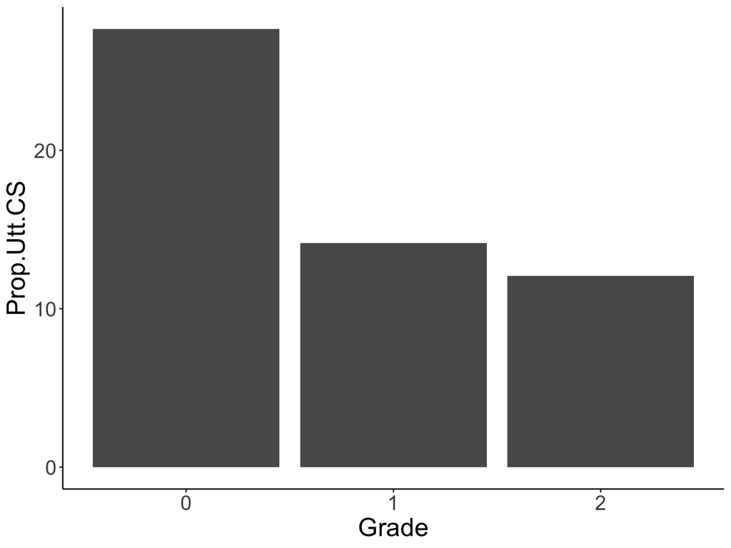

```r
p <- ggplot(df_no_out, aes(x=Grade, y=Prop.Utt.CS)) +
  geom_bar(stat="identity") + julie.theme + theme(text = element_text(size=20)) +  scale_fill_manual(values=c("#E69F00"))
p
```

## 0.10 Plot Prop of Utterances across languages and waves

```r
Prop.CS.aov <- aov(Prop.Utt.CS ~ Language*wave, data = df_no_out)
summary(Prop.CS.aov)
```

```
##                 Df Sum Sq  Mean Sq F value  Pr(>F)
## Language         1  0.000 0.000002   0.000 0.98376
## wave             1  0.023 0.023096   6.288 0.01222 *
## Language:wave    1  0.028 0.028302   7.705 0.00555 **
## Residuals     2336  8.580 0.003673
## ---
## Signif. codes:  0 '***' 0.001 '**' 0.01 '*' 0.05 '.' 0.1 ' ' 1
```

```r
fall_df <- df_no_out[which(df_no_out$wave == 'fall'),]
spring_df <- df_no_out[which(df_no_out$wave == 'spring'),]

t.test(spring_df$Prop.Utt.CS~spring_df$Language, paired = TRUE)
```

```
##
##  Paired t-test
##
## data:  spring_df$Prop.Utt.CS by spring_df$Language
## t = -2.1737, df = 584, p-value = 0.03013
## alternative hypothesis: true difference in means is not equal to 0
## 95 percent confidence interval:
##  -0.013337376 -0.000675825
## sample estimates:
## mean of the differences
##            -0.007006601
```

```r
t.test(fall_df$Prop.Utt.CS~fall_df$Language, paired = TRUE)
```

```
##
##  Paired t-test
##
## data:  fall_df$Prop.Utt.CS by fall_df$Language
## t = 1.7823, df = 584, p-value = 0.07522
## alternative hypothesis: true difference in means is not equal to 0
## 95 percent confidence interval:
##  -0.0007039542  0.0145131442
## sample estimates:
## mean of the differences
##             0.006904595
```

```r
t.test(eng_df$Prop.Utt.CS~eng_df$wave, paired = TRUE)
```

```
##
##  Paired t-test
##
## data:  eng_df$Prop.Utt.CS by eng_df$wave
## t = 3.9643, df = 584, p-value = 8.273e-05
## alternative hypothesis: true difference in means is not equal to 0
## 95 percent confidence interval:
##  0.006680014 0.019797821
## sample estimates:
## mean of the differences
##              0.01323892
```

```r
t.test(span_df$Prop.Utt.CS~span_df$wave, paired = TRUE)
```

```
##
##  Paired t-test
##
## data:  span_df$Prop.Utt.CS by span_df$wave
## t = -0.2671, df = 584, p-value = 0.7895
## alternative hypothesis: true difference in means is not equal to 0
## 95 percent confidence interval:
##  -0.005615749  0.004271194
## sample estimates:
## mean of the differences
##           -0.0006722777
```

```r
df_no_out %>%
  group_by(Language,wave) %>%
  summarise_at(vars(Prop.Utt.CS), funs(mean(., na.rm=TRUE)))
```

```
## # A tibble: 4 x 3
## # Groups:   Language [2]
##   Language wave   Prop.Utt.CS
##   <fct>    <fct>        <dbl>
## 1 ENGLISH  fall        0.0296
## 2 ENGLISH  spring      0.0164
## 3 SPANISH  fall        0.0227
## 4 SPANISH  spring      0.0234
```

### 0.10.1 Calculate means and SE for each group of interest

### 0.10.2 Plot means and SE

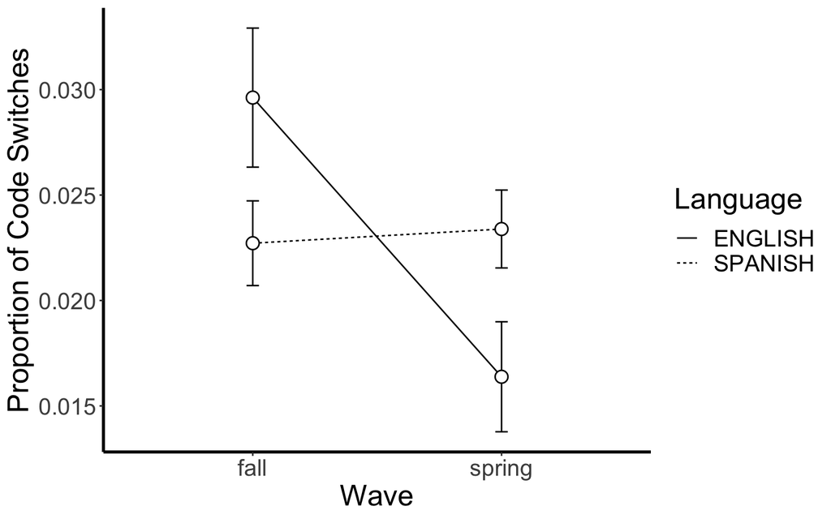

```r
pd <- position_dodge(width = 0)
sum_d %>%
  ggplot(aes(x = wave, y = CS_prop_mean, group = Language)) +
    geom_line(aes(linetype = Language), position = pd) +
    geom_errorbar(aes(ymin = CS_prop_mean - se, ymax = CS_prop_mean + se),
                  width = .1, position = pd) +
    geom_point(size = 4, position = pd) +
    geom_point(size = 3, color = "white", position = pd) +
    guides(linetype = guide_legend("Language")) +
    labs(x = "Wave",
         y = "Proportion of Code Switches") +
  theme(
    text=element_text(size=20),
    panel.background = element_rect(fill = "white"),         # Set plot background to white
    legend.key  = element_rect(fill = "white"),              # Set legend item backgrounds to white
    axis.line.x = element_line(colour = "black", size = 1),  # Add line to x axis
    axis.line.y = element_line(colour = "black", size = 1)   # Add line to y axis
  )
```

## 0.11 Table of Demographic Information

```r
catvars <- c("Gender", "wave", "Grade","Language")
myvars <- c("Gender", "wave","Prop.Utt.CS", "NTW.withinlang", "NDW.withinlang","MLUw.A")
table2 <- CreateTableOne(myvars, df_no_out, catvars, strata = c("Language","Grade"))
table2
```

```
##                             Stratified by Language:Grade
##                              ENGLISH:0      SPANISH:0      ENGLISH:1
##   n                             390            390            390
##   Gender = M (%)                164 (42.1)     164 (42.1)     163 (41.8)
##   wave = spring (%)             195 (50.0)     195 (50.0)     195 (50.0)
##   Prop.Utt.CS (mean (SD))      0.05 (0.11)    0.02 (0.05)    0.01 (0.05)
##   NTW.withinlang (mean (SD)) 181.04 (84.98) 155.24 (71.54) 284.11 (102.62)
##   NDW.withinlang (mean (SD))  62.97 (23.18)  65.00 (21.14)  83.88 (22.00)
##   MLUw.A (mean (SD))           6.20 (1.28)    5.30 (1.13)    6.83 (0.85)
##                             Stratified by Language:Grade
##                              SPANISH:1      ENGLISH:2      SPANISH:2
##   n                             390            390            390
##   Gender = M (%)                163 (41.8)     164 (42.1)     164 (42.1)
##   wave = spring (%)             195 (50.0)     195 (50.0)     195 (50.0)
##   Prop.Utt.CS (mean (SD))      0.02 (0.05)    0.01 (0.02)    0.02 (0.04)
##   NTW.withinlang (mean (SD)) 235.89 (90.76) 303.71 (78.19) 244.74 (69.37)
##   NDW.withinlang (mean (SD))  82.27 (21.01)  98.32 (21.23)  87.91 (17.97)
##   MLUw.A (mean (SD))           5.86 (0.89)    7.48 (1.20)    6.47 (1.18)
##                             Stratified by Language:Grade
##                              p      test
##   n
##   Gender = M (%)              1.000
##   wave = spring (%)           1.000
##   Prop.Utt.CS (mean (SD))    <0.001
##   NTW.withinlang (mean (SD)) <0.001
##   NDW.withinlang (mean (SD)) <0.001
##   MLUw.A (mean (SD))         <0.001
```

## 0.12 Multiple Regression: What factors are driving these difference in code switching behaviors across languages?

## 0.13 Plot NDW and NTW across languages and grades

```r
NTW.aov <- aov(NTW.withinlang ~ Language*Grade, data = df_no_out)
summary(NTW.aov)
```

```
##                  Df   Sum Sq Mean Sq F value   Pr(>F)
## Language          1  1149475 1149475  156.67  < 2e-16 ***
## Grade             1  4388933 4388933  598.20  < 2e-16 ***
## Language:Grade    1   107319  107319   14.63 0.000134 ***
## Residuals      2336 17138885    7337
## ---
## Signif. codes:  0 '***' 0.001 '**' 0.01 '*' 0.05 '.' 0.1 ' ' 1
```

```r
t.test(k_df$NTW.withinlang~k_df$Language, paired = TRUE, alternative = "two.sided")
```

```
##
##  Paired t-test
##
## data:  k_df$NTW.withinlang by k_df$Language
## t = 6.9378, df = 389, p-value = 1.672e-11
## alternative hypothesis: true difference in means is not equal to 0
## 95 percent confidence interval:
##  18.48491 33.10484
## sample estimates:
## mean of the differences
##                25.79487
```

```r
t.test(first_df$NTW.withinlang~first_df$Language, paired = TRUE, alternative = "two.sided")
```

```
##
##  Paired t-test
##
## data:  first_df$NTW.withinlang by first_df$Language
## t = 8.1256, df = 389, p-value = 5.981e-15
## alternative hypothesis: true difference in means is not equal to 0
## 95 percent confidence interval:
##  36.54915 59.88162
## sample estimates:
## mean of the differences
##                48.21538
```

```r
t.test(second_df$NTW.withinlang~second_df$Language, paired = TRUE, alternative = "two.sided")
```

```
##
##  Paired t-test
##
## data:  second_df$NTW.withinlang by second_df$Language
## t = 13.431, df = 389, p-value < 2.2e-16
## alternative hypothesis: true difference in means is not equal to 0
## 95 percent confidence interval:
##  50.33953 67.60406
## sample estimates:
## mean of the differences
##                58.97179
```

```r
d <- df_no_out %>%
       select(NTW.withinlang,Language,Grade) %>%  # select relevant variables
       mutate(Language = factor(Language),
              Grade = factor(Grade))

head(d)
```

```
##   NTW.withinlang Language Grade
## 1            237  ENGLISH     1
## 2            304  ENGLISH     1
## 3            178  ENGLISH     1
## 4            226  ENGLISH     1
## 5            305  ENGLISH     1
## 6            137  ENGLISH     1
```

```r
d %>%
  group_by(Language, Grade) %>%
  summarise(NTW.withinlang_mean = mean(NTW.withinlang))
```

```
## # A tibble: 6 x 3
## # Groups:   Language [2]
##   Language Grade NTW.withinlang_mean
##   <fct>    <fct>               <dbl>
## 1 ENGLISH  0                    181.
## 2 ENGLISH  1                    284.
## 3 ENGLISH  2                    304.
## 4 SPANISH  0                    155.
## 5 SPANISH  1                    236.
## 6 SPANISH  2                    245.
```

```r
sum_d <- d %>%
          group_by(Language, Grade) %>%
          summarise(NTW.withinlang_mean = mean(NTW.withinlang),
                    se   = sd(NTW.withinlang)/sqrt(n()))
sum_d
```

```
## # A tibble: 6 x 4
## # Groups:   Language [2]
##   Language Grade NTW.withinlang_mean    se
##   <fct>    <fct>               <dbl> <dbl>
## 1 ENGLISH  0                    181.  4.30
## 2 ENGLISH  1                    284.  5.20
## 3 ENGLISH  2                    304.  3.96
## 4 SPANISH  0                    155.  3.62
## 5 SPANISH  1                    236.  4.60
## 6 SPANISH  2                    245.  3.51
```

### 0.13.1 Plot means and SE

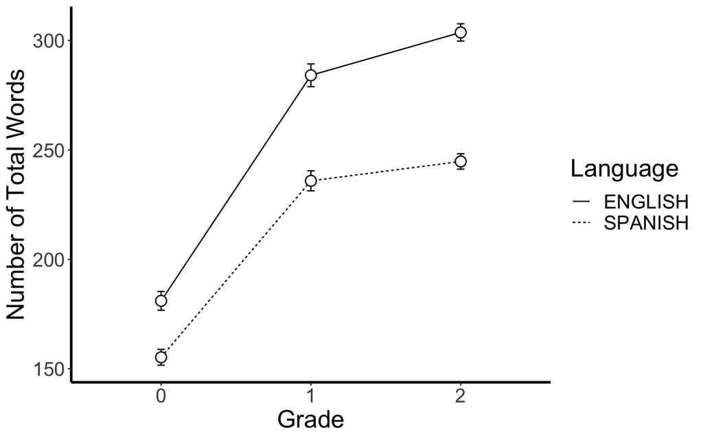

```r
pd <- position_dodge(width = 0)
sum_d %>%
  ggplot(aes(x = Grade, y = NTW.withinlang_mean, group = Language)) +
    geom_line(aes(linetype = Language), position = pd) +
    geom_errorbar(aes(ymin = NTW.withinlang_mean - se, ymax = NTW.withinlang_mean + se),
                  width = .1, position = pd) +
    geom_point(size = 4, position = pd) +
    geom_point(size = 3, color = "white", position = pd) +
    guides(linetype = guide_legend("Language")) +
    labs(x = "Grade",
         y = "Number of Total Words") +
  theme(
    text=element_text(size=20),
    panel.background = element_rect(fill = "white"),         # Set plot background to white
    legend.key  = element_rect(fill = "white"),              # Set legend item backgrounds to white
    axis.line.x = element_line(colour = "black", size = 1),  # Add line to x axis
    axis.line.y = element_line(colour = "black", size = 1)   # Add line to y axis
  )
```

```r
NDW.aov <- aov(NTW.withinlang ~ Language*Grade, data = df_no_out)
summary(NDW.aov)
```

```
##                  Df   Sum Sq Mean Sq F value   Pr(>F)
## Language          1  1149475 1149475  156.67  < 2e-16 ***
## Grade             1  4388933 4388933  598.20  < 2e-16 ***
## Language:Grade    1   107319  107319   14.63 0.000134 ***
## Residuals      2336 17138885    7337
## ---
## Signif. codes:  0 '***' 0.001 '**' 0.01 '*' 0.05 '.' 0.1 ' ' 1
```

```r
t.test(k_df$NDW.withinlang~k_df$Language, paired = TRUE, alternative = "two.sided")
```

```
##
##  Paired t-test
##
## data:  k_df$NDW.withinlang by k_df$Language
## t = -1.7862, df = 389, p-value = 0.07485
## alternative hypothesis: true difference in means is not equal to 0
## 95 percent confidence interval:
##  -4.2714591  0.2047924
## sample estimates:
## mean of the differences
##               -2.033333
```

```r
t.test(first_df$NDW.withinlang~first_df$Language, paired = TRUE, alternative = "two.sided")
```

```
##
##  Paired t-test
##
## data:  first_df$NDW.withinlang by first_df$Language
## t = 1.1551, df = 389, p-value = 0.2487
## alternative hypothesis: true difference in means is not equal to 0
## 95 percent confidence interval:
##  -1.130472  4.350985
## sample estimates:
## mean of the differences
##                1.610256
```

```r
t.test(second_df$NDW.withinlang~second_df$Language, paired = TRUE, alternative = "two.sided")
```

```
##
##  Paired t-test
##
## data:  second_df$NDW.withinlang by second_df$Language
## t = 8.9475, df = 389, p-value < 2.2e-16
## alternative hypothesis: true difference in means is not equal to 0
## 95 percent confidence interval:
##   8.122745 12.697767
## sample estimates:
## mean of the differences
##                10.41026
```

```r
d <- df_no_out %>%
       select(NDW.withinlang,Language,Grade) %>%  # select relevant variables
       mutate(Language = factor(Language),
              Grade = factor(Grade))

head(d)
```

```
##   NDW.withinlang Language Grade
## 1             74  ENGLISH     1
## 2            102  ENGLISH     1
## 3             64  ENGLISH     1
## 4             66  ENGLISH     1
## 5             96  ENGLISH     1
## 6             50  ENGLISH     1
```

```r
d %>%
  group_by(Language, Grade) %>%
  summarise(NDW.withinlang_mean = mean(NDW.withinlang))
```

```
## # A tibble: 6 x 3
## # Groups:   Language [2]
##   Language Grade NDW.withinlang_mean
##   <fct>    <fct>               <dbl>
## 1 ENGLISH  0                    63.0
## 2 ENGLISH  1                    83.9
## 3 ENGLISH  2                    98.3
## 4 SPANISH  0                    65.0
## 5 SPANISH  1                    82.3
## 6 SPANISH  2                    87.9
```

```r
sum_d <- d %>%
          group_by(Language, Grade) %>%
          summarise(NDW.withinlang_mean = mean(NDW.withinlang),
                    se   = sd(NDW.withinlang)/sqrt(n()))
sum_d
```

```
## # A tibble: 6 x 4
## # Groups:   Language [2]
##   Language Grade NDW.withinlang_mean    se
##   <fct>    <fct>               <dbl> <dbl>
## 1 ENGLISH  0                    63.0 1.17
## 2 ENGLISH  1                    83.9 1.11
## 3 ENGLISH  2                    98.3 1.07
## 4 SPANISH  0                    65.0 1.07
## 5 SPANISH  1                    82.3 1.06
## 6 SPANISH  2                    87.9 0.910
```

### 0.13.2 Plot means and SE

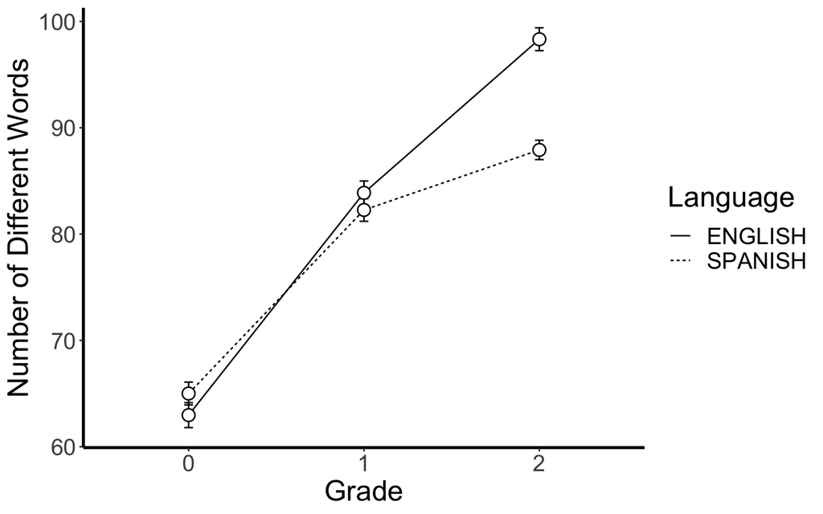

```r
pd <- position_dodge(width = 0)
sum_d %>%
  ggplot(aes(x = Grade, y = NDW.withinlang_mean, group = Language)) +
    geom_line(aes(linetype = Language), position = pd) +
    geom_errorbar(aes(ymin = NDW.withinlang_mean - se, ymax = NDW.withinlang_mean + se),
                  width = .1, position = pd) +
    geom_point(size = 4, position = pd) +
    geom_point(size = 3, color = "white", position = pd) +
    guides(linetype = guide_legend("Language")) +
    labs(x = "Grade",
         y = "Number of Different Words") +
  theme(
    text=element_text(size=20),
    panel.background = element_rect(fill = "white"),         # Set plot background to white
    legend.key  = element_rect(fill = "white"),              # Set legend item backgrounds to white
    axis.line.x = element_line(colour = "black", size = 1),  # Add line to x axis
    axis.line.y = element_line(colour = "black", size = 1)   # Add line to y axis
  )
```

## 0.14 Proficiency Analysis

Individuals with a more *negative* NTW or NDW score had a greater proficiency in Spanish at that data point; a more *positive* NTW or NDW score means they have greater proficiency in English at that data point.

The older children got, the less likely they were to code switch on the English task. Individuals with more different words in English were more likely to code switch on the Spanish task.

```r
colnames(eng_df)[which(names(eng_df) == "Prop.Utt.CS")] <- "eng.Prop.Utt.CS"
colnames(span_df)[which(names(span_df) == "Prop.Utt.CS")] <- "span.Prop.Utt.CS"

diff_df <- merge(eng_df,span_df,by=c("subject","wave","Grade"),all.x = T)
colnames(diff_df)[which(names(diff_df) == "NTW.withinlang.x")] <- "NTW.eng"
colnames(diff_df)[which(names(diff_df) == "NTW.withinlang.y")] <- "NTW.span"
colnames(diff_df)[which(names(diff_df) == "NDW.withinlang.x")] <- "NDW.eng"
colnames(diff_df)[which(names(diff_df) == "NDW.withinlang.y")] <- "NDW.span"

diff_df$NTW.diff <- diff_df$NTW.eng - diff_df$NTW.span
diff_df$NDW.diff <- diff_df$NDW.eng - diff_df$NDW.span

eng.simple.model <- lmer(eng.Prop.Utt.CS ~ Gender.x + Grade + wave + NTW.diff + NDW.diff + (1|subject), data = diff_df)
summary(eng.simple.model)
```

```
## Linear mixed model fit by REML. t-tests use Satterthwaite's method [
## lmerModLmerTest]
## Formula:
## eng.Prop.Utt.CS ~ Gender.x + Grade + wave + NTW.diff + NDW.diff +
##     (1 | subject)
##    Data: diff_df
##
## REML criterion at convergence: -2925.1
##
## Scaled residuals:
##     Min      1Q  Median      3Q     Max
## -2.6223 -0.4187 -0.1195  0.1505 10.7901
##
## Random effects:
##  Groups   Name        Variance  Std.Dev.
##  subject  (Intercept) 0.0007826 0.02797
##  Residual             0.0039864 0.06314
## Number of obs: 1170, groups:  subject, 195
##
## Fixed effects:
##               Estimate Std. Error         df t value Pr(>|t|)
## (Intercept)  4.985e-02  5.080e-03  5.971e+02   9.814  < 2e-16 ***
## Gender.xM    2.726e-03  5.546e-03  1.953e+02   0.492  0.62357
## Grade       -1.854e-02  2.352e-03  1.019e+03  -7.882 8.27e-15 ***
## wavespring  -1.137e-02  3.750e-03  9.879e+02  -3.032  0.00249 **
## NTW.diff    -6.918e-05  4.590e-05  1.143e+03  -1.507  0.13198
## NDW.diff    -2.114e-04  1.726e-04  1.126e+03  -1.225  0.22087
## ---
## Signif. codes:  0 '***' 0.001 '**' 0.01 '*' 0.05 '.' 0.1 ' ' 1
##
## Correlation of Fixed Effects:
##            (Intr) Gndr.M Grade  wvsprn NTW.df
## Gender.xM  -0.489
## Grade      -0.488  0.029
## wavespring -0.414  0.017  0.046
## NTW.diff   -0.388  0.058  0.042  0.086
## NDW.diff    0.407 -0.105 -0.197 -0.161 -0.802
```

```r
effectsize(eng.simple.model)
```

```
## Parameter   | Coefficient (std.) |         95% CI
## -------------------------------------------------
## (Intercept) |               0.06 | [-0.05,  0.17]
## Gender.xM   |               0.04 | [-0.11,  0.19]
## Grade       |              -0.21 | [-0.26, -0.16]
## wavespring  |              -0.16 | [-0.26, -0.06]
## NTW.diff    |              -0.07 | [-0.17,  0.02]
## NDW.diff    |              -0.06 | [-0.17,  0.04]
```

```r
diff_df %>%
  group_by(wave) %>%
  summarise(eng.Prop.Utt.CS = mean(eng.Prop.Utt.CS))
```

```
## # A tibble: 2 x 2
##   wave   eng.Prop.Utt.CS
##   <fct>            <dbl>
## 1 fall            0.0296
## 2 spring          0.0164
```

```r
t.test(diff_df$eng.Prop.Utt.CS~diff_df$wave, paired = TRUE, alternative = "two.sided")
```

```
##
##  Paired t-test
##
## data:  diff_df$eng.Prop.Utt.CS by diff_df$wave
## t = 3.9643, df = 584, p-value = 8.273e-05
## alternative hypothesis: true difference in means is not equal to 0
## 95 percent confidence interval:
##  0.006680014 0.019797821
## sample estimates:
## mean of the differences
##              0.01323892
```

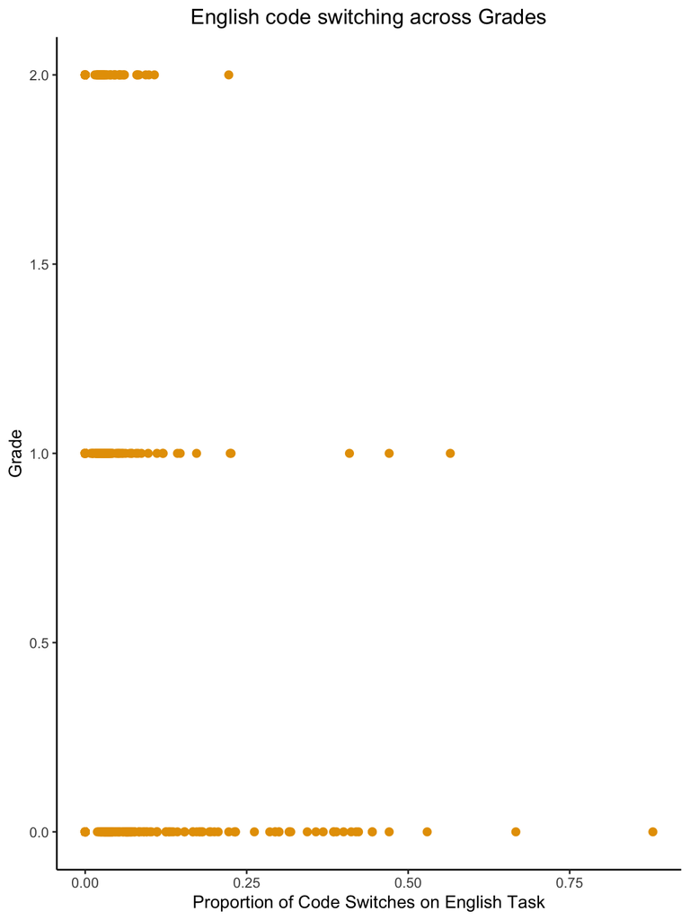

```r
ggplot(diff_df, aes(x=eng.Prop.Utt.CS, y = Grade)) + labs(title="English code switching across Grades", x="Proportion of Code Switches on English Task", y = "Grade") + geom_point(size=2,color='#E69F00') + julie.theme+ theme(plot.title = element_text(hjust = 0.5))
```

```r
span.simple.model <- lmer(span.Prop.Utt.CS ~ Gender.x + Grade + wave + NTW.diff + NDW.diff + (1|subject), data = diff_df)
summary(span.simple.model)
```

```
## Linear mixed model fit by REML. t-tests use Satterthwaite's method [
## lmerModLmerTest]
## Formula:
## span.Prop.Utt.CS ~ Gender.x + Grade + wave + NTW.diff + NDW.diff +
##     (1 | subject)
##    Data: diff_df
##
## REML criterion at convergence: -3882.4
##
## Scaled residuals:
##     Min      1Q  Median      3Q     Max
## -2.3821 -0.4557 -0.2534  0.2207 10.0666
##
## Random effects:
##  Groups   Name        Variance  Std.Dev.
##  subject  (Intercept) 0.0003322 0.01823
##  Residual             0.0017574 0.04192
## Number of obs: 1170, groups:  subject, 195
##
## Fixed effects:
##               Estimate Std. Error         df t value Pr(>|t|)
## (Intercept)  2.377e-02  3.355e-03  5.913e+02   7.084    4e-12 ***
## Gender.xM    3.021e-03  3.646e-03  1.885e+02   0.829 0.408431
## Grade       -1.128e-03  1.561e-03  1.014e+03  -0.723 0.469994
## wavespring  -1.445e-03  2.490e-03  9.816e+02  -0.580 0.561935
## NTW.diff    -3.595e-05  3.044e-05  1.144e+03  -1.181 0.237818
## NDW.diff     4.395e-04  1.143e-04  1.121e+03   3.845 0.000127 ***
## ---
## Signif. codes:  0 '***' 0.001 '**' 0.01 '*' 0.05 '.' 0.1 ' ' 1
##
## Correlation of Fixed Effects:
##            (Intr) Gndr.M Grade  wvsprn NTW.df
## Gender.xM  -0.488
## Grade      -0.490  0.029
## wavespring -0.416  0.018  0.045
## NTW.diff   -0.389  0.058  0.042  0.086
## NDW.diff    0.408 -0.105 -0.196 -0.160 -0.803
```

```r
effectsize(span.simple.model)
```

```
## Parameter   | Coefficient (std.) |        95% CI
## ------------------------------------------------
## (Intercept) |              -0.01 | [-0.12, 0.10]
## Gender.xM   |               0.06 | [-0.09, 0.22]
## Grade       |              -0.02 | [-0.07, 0.03]
## wavespring  |              -0.03 | [-0.14, 0.07]
## NTW.diff    |              -0.06 | [-0.16, 0.04]
## NDW.diff    |               0.21 | [ 0.10, 0.31]
```

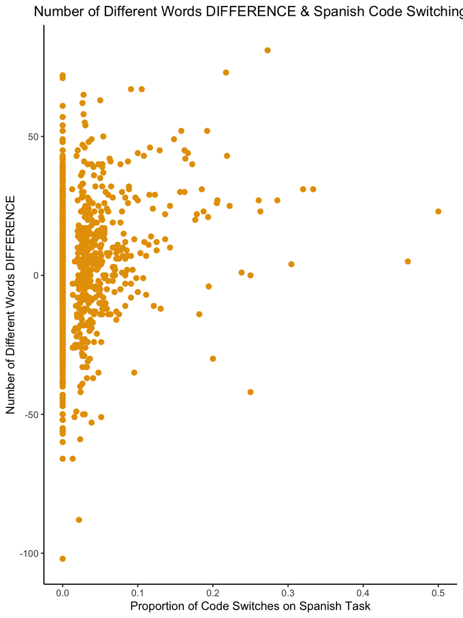

```r
ggplot(diff_df, aes(x=span.Prop.Utt.CS, y = NDW.diff)) + labs(title="Number of Different Words DIFFERENCE & Spanish Code Switching", x="Proportion of Code Switches on Spanish Task", y = "Number of Different Words DIFFERENCE") + geom_point(size=2,color='#E69F00') + julie.theme+ theme(plot.title = element_text(hjust = 0.5))
```

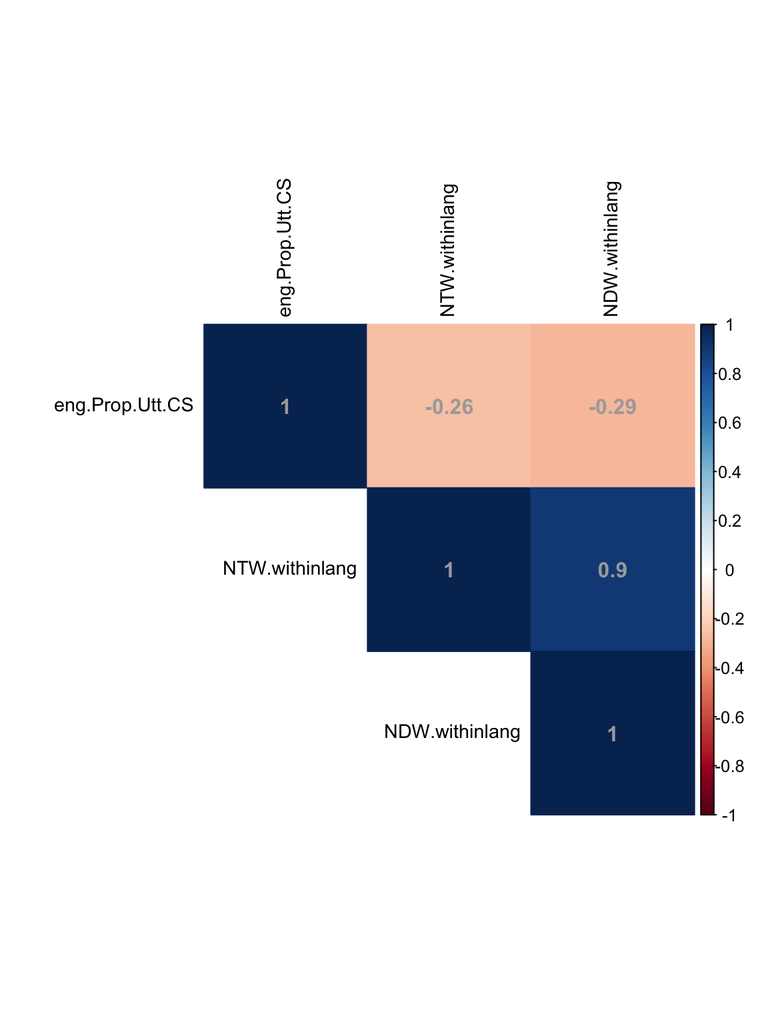

```r
mycorrvars <- c("eng.Prop.Utt.CS", "NTW.withinlang", "NDW.withinlang")
df_eng_subset <- eng_df[mycorrvars]
overall_corr<-rcorr(as.matrix(df_eng_subset))
corrplot(overall_corr$r, method = "color", type = "upper",addCoef.col="dark grey", tl.col = "black", p.mat = overall_corr$P, sig.level = 0.05, insig = "blank", tl.cex = 0.9)
```

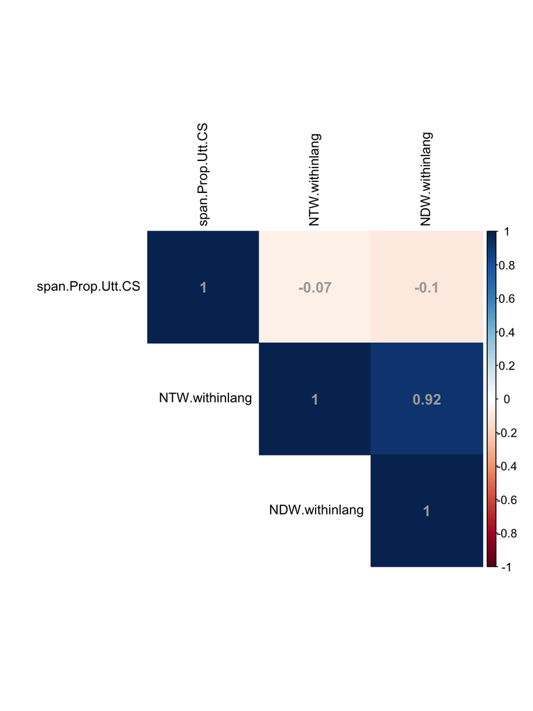

```r
mycorrvars <- c("span.Prop.Utt.CS", "NTW.withinlang", "NDW.withinlang")
df_span_subset <- span_df[mycorrvars]
overall_corr<-rcorr(as.matrix(df_span_subset))
corrplot(overall_corr$r, method = "color", type = "upper",addCoef.col="dark grey", tl.col = "black", p.mat = overall_corr$P, sig.level = 0.05, insig = "blank", tl.cex = 0.9)
```